# Day 1 - Methods

03/05/2018

## Data Handling & Visualisation

```r
# load data
data = AirPassengers

# basic statistics
summary(data)
```

```
##    Min. 1st Qu.  Median    Mean 3rd Qu.    Max.
##   104.0   180.0   265.5   280.3   360.5   622.0
```

## Visualisation

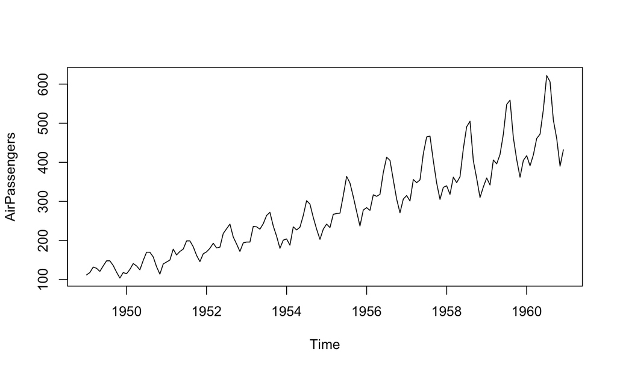

```r
plot(AirPassengers)
```

## Data Inspection

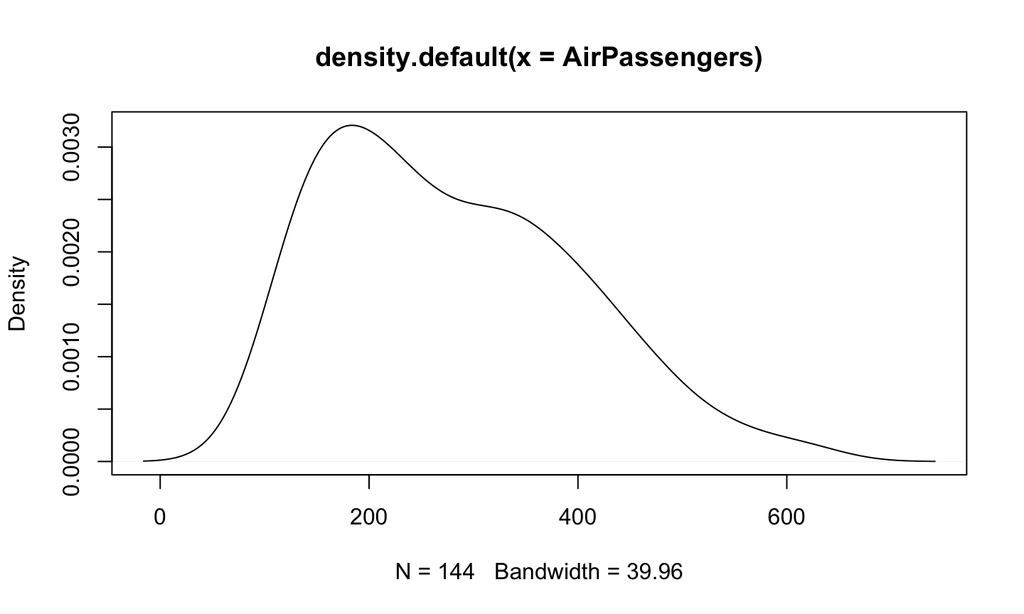

```r
plot(density(AirPassengers))
```

## Decompositon

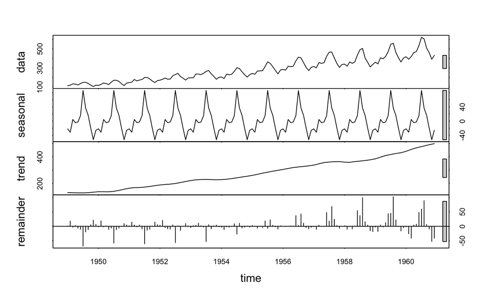

```r
library(forecast)
fit <- stl(AirPassengers, t.window=15, s.window="periodic", robust=TRUE)
plot(fit)
```

## Seasonal Analysis

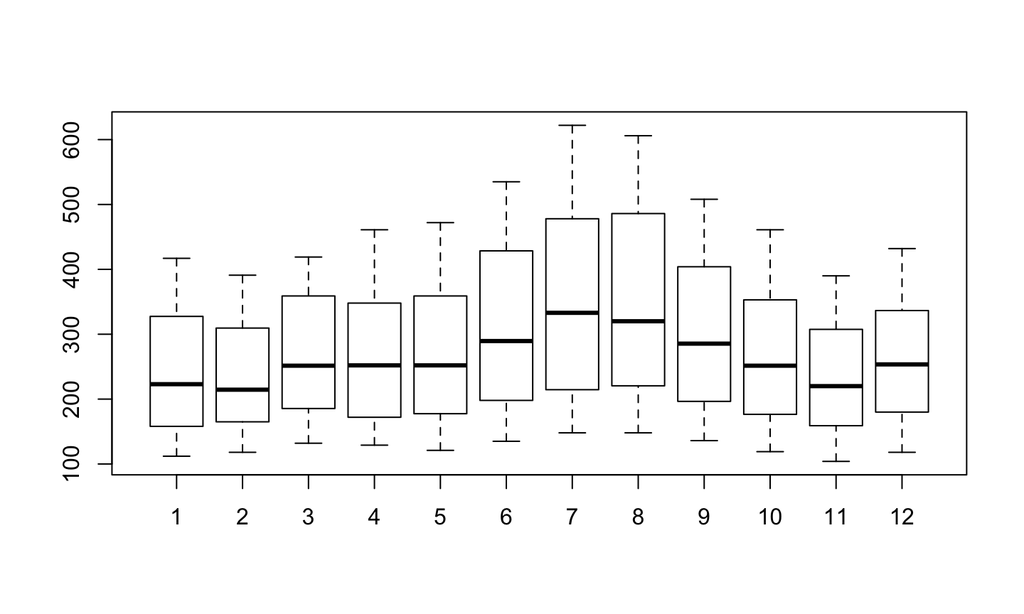

```r
boxplot(AirPassengers~cycle(AirPassengers))
```

## The `forecast` package

## The `forecast` package

- The holy grail of R time series forecasting
- Includes all the traditional models
- AR
- MA
- ARIMA
- …

## Basic Forecasting Methods

Simple Average \[\hat{y}_{T+h|T} = \bar{y} = (y_{1}+\dots+y_{T})/T\] Naïve Method \[\hat{y}_{T+h|T} = y_{T}\] Seasonal Naïve Method \[\hat{y}_{T+h|T} = y_{T+h-m(k+1)}\]

## Comparing Basic Forecasting Methods

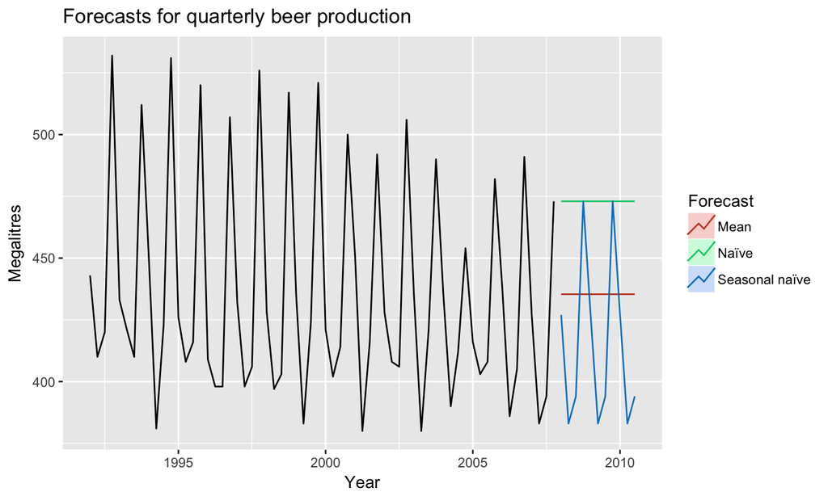

## That's TS Forecasting

## Predict using Moving Average (MA)

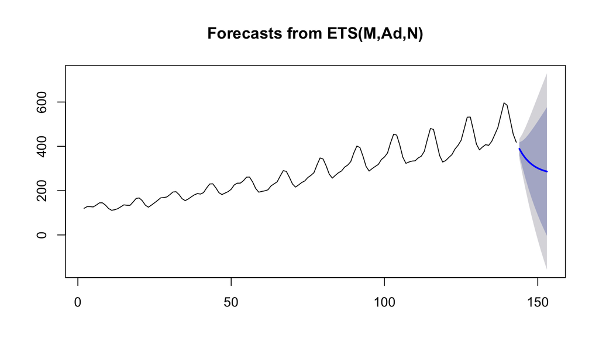

```r
data = ts(AirPassengers) # convert to ts object
model = ma(data, order=2)
forecast = forecast(model, h=10)
plot(forecast)
```

## Predict using Moving Average (MA)

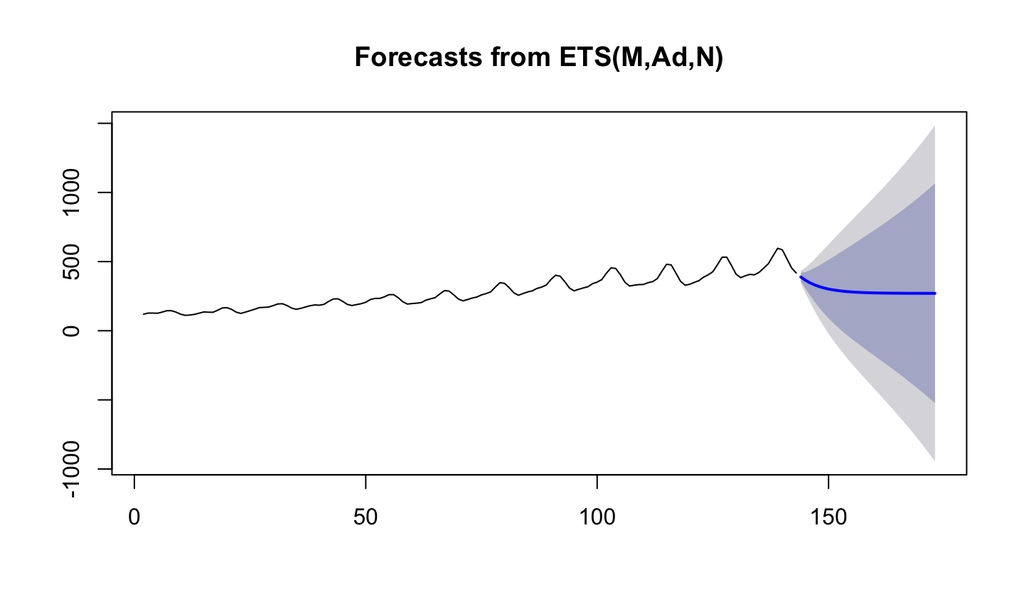

```r
data = ts(AirPassengers) # convert to ts object
model = ma(data, order=2)
forecast = forecast(model, h=30)
plot(forecast)
```

## That's also TS Forecasting

## Prediction Intervals

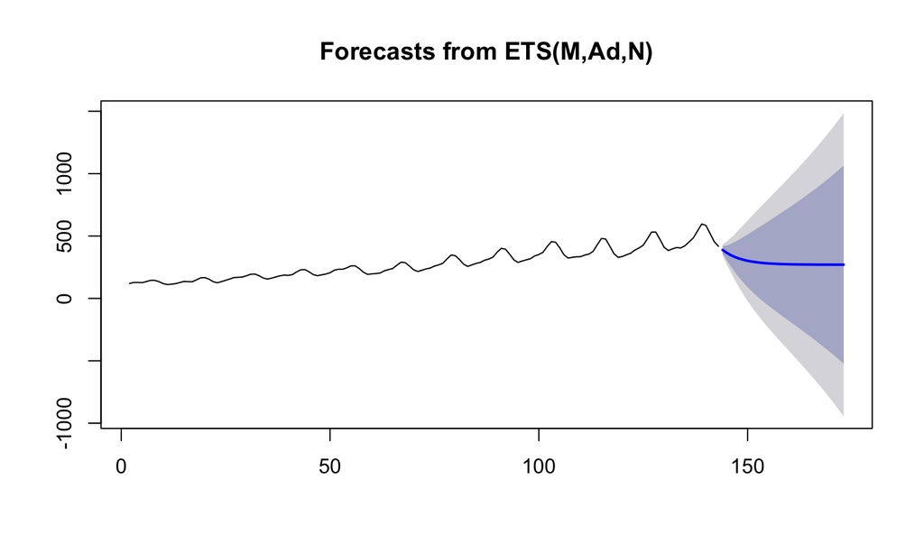

https://www.otexts.org/fpp2/prediction-intervals.html

## Predict using Auto Regression (AR)

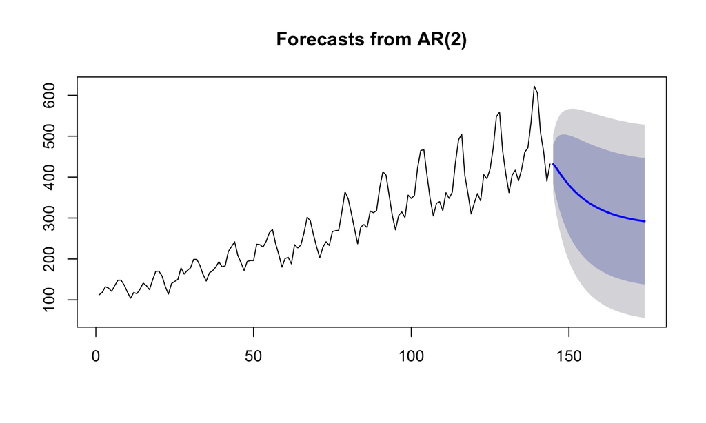

```r
data = ts(AirPassengers) # convert to ts object
model = ar(data, order=5)
forecast = forecast(model, h=30)
plot(forecast)
```

## Predict using Auto Regression (AR)

#### AR(10)

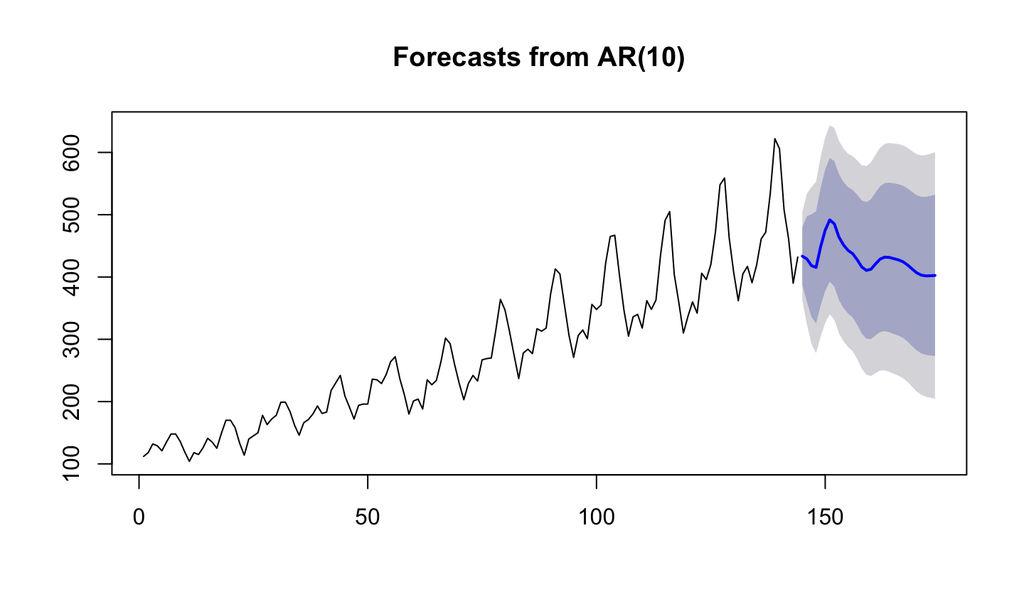

```r
data = ts(AirPassengers) # convert to ts object
model = ar(data, order=10)
forecast = forecast(model, h=30)
plot(forecast)
```

## Predict using Auto Regression (AR)

Higher order, higher pattern recognition (now AR(13))

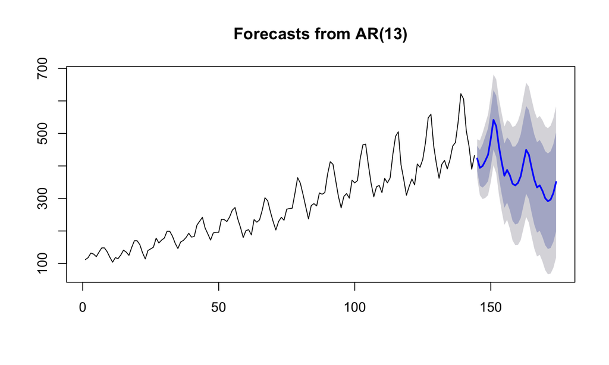

```r
data = ts(AirPassengers) # convert to ts object
model = ar(data, order=13)
forecast = forecast(model, h=30)
plot(forecast)
```

## Predict using Auto Regression (AR)

Long time-frames: mean-convergence and zero trend

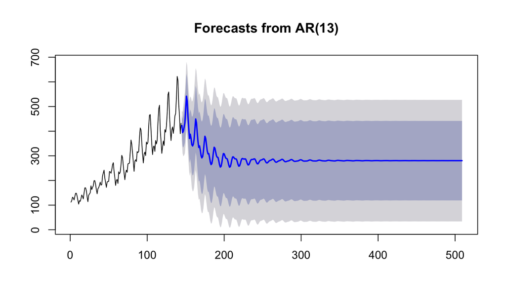

```r
data = ts(AirPassengers) # convert to ts object
model = ar(data, order=20)
forecast = forecast(model, h=365)
plot(forecast)
```

## Predict using auto.ARIMA

\[AR + I + MA\]

or rather

\[AR(x) + I(x) + MA(x)\] where \(x\) is the 'order' (plain english: how often it is applied)

## What is \(I\)?

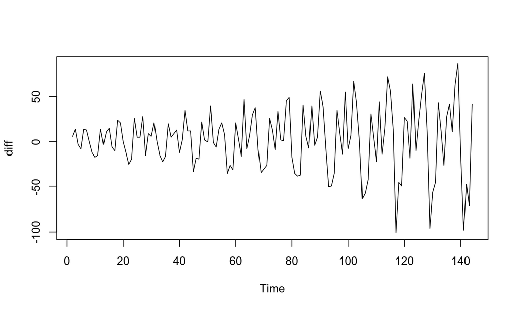

```r
data = ts(AirPassengers) # convert to ts object
diff = diff(data, differences = 1) # create I of n-th order
plot(diff)
```

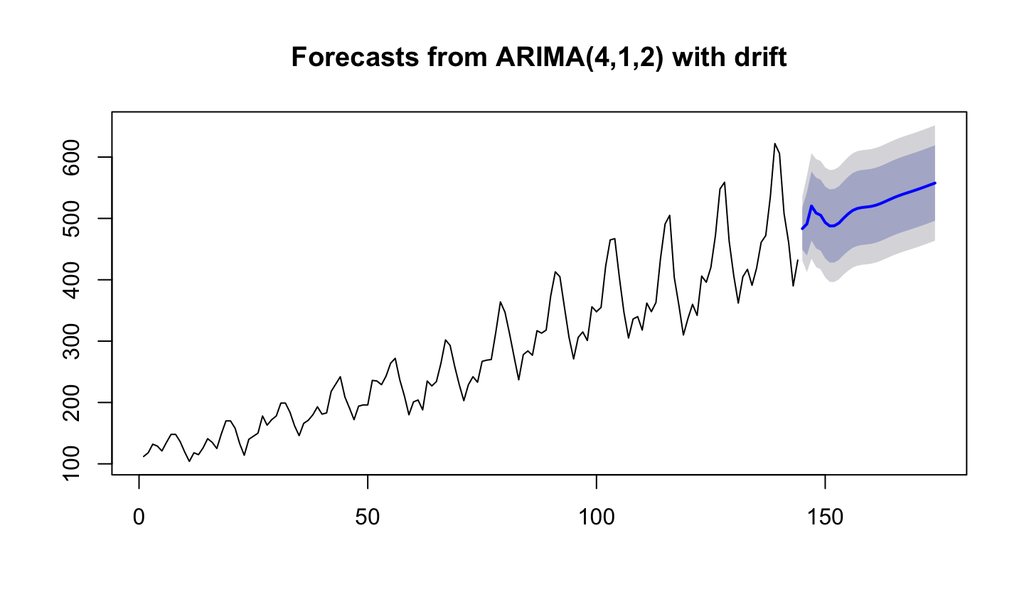

```r
data = ts(AirPassengers)
model = auto.arima(data)
forecast = forecast(model, h=30)
plot(forecast)
```

## Long-Term Forecast using auto.ARIMA

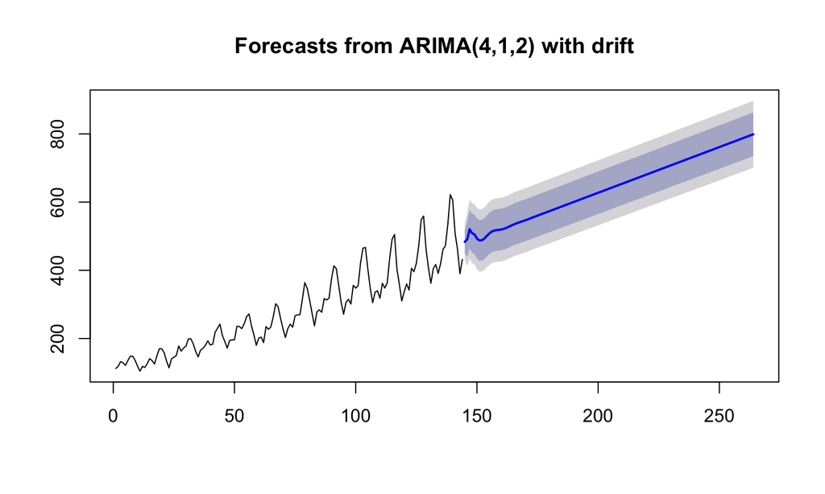

```r
data = ts(AirPassengers)
model = auto.arima(data)
forecast = forecast(model, h=120)
plot(forecast)
```

## Practical Challenge

## Predict `mdeaths`

- Predict `mdeaths` with `auto.arima` for 3 years
- `mdeaths` is split into months, hence one year equals `h=12`
- The dataset:

```r
data = ts(mdeaths)
```

## Solution

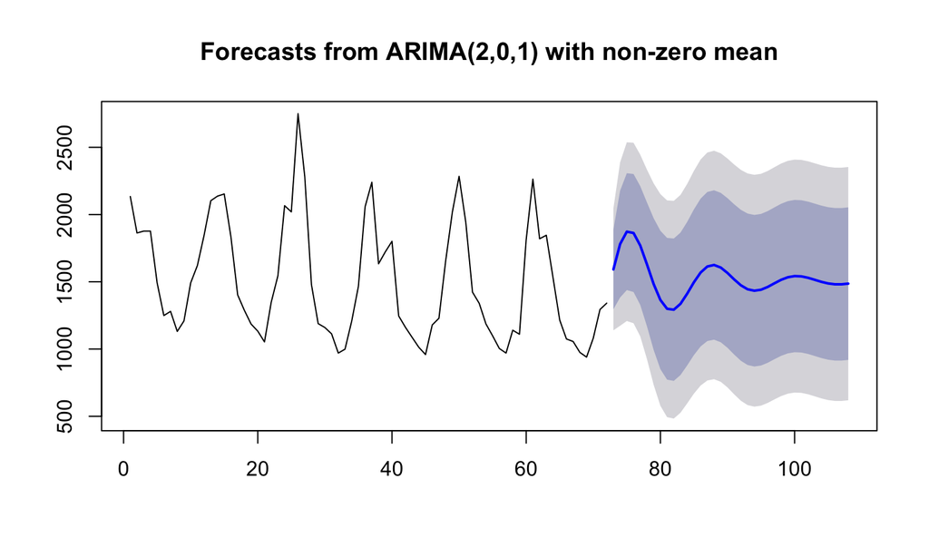

```r
data = ts(mdeaths)
model = auto.arima(data)
forecast = forecast(model, h=36)
plot(forecast)
```

## What to do?

- Change forecast method
- Transform data
- Tune \(AR(x) + I(x) + MA(x)\) orders manually

## Recap

## Recap

- Forecasting can be as simple as taking the average
- More complex forecasting follows the same approach: extrapolating from the past
- The `forecast` package is the holy grail of forecasting
- `auto.arima()` provides a way to do automated forecasting with classic methods

## Cutting-edge forecasting with `prophet`

## Traditional Methods

- Not made for large-scale data
- Need a lot of manual inspection and tuning
- Sensitive to outliers and missing data
- Requires an in-house specialist in **each** department
- In short: costly to deploy & to scale

## Modern Methods

- Generalised Additive Models
- Memoryless Neural Networks (NN)
- Recurrent Neural Networks (RNN/LTSM)

## Modern Method: `prophet`

https://research.fb.com/prophet-forecasting-at-scale/

## Modern Method: `prophet`

```r
m = prophet(df)
future <- make_future_dataframe(m, periods = 12, freq = 'month')
forecast <- predict(m, future)
```

## Modern Method: `prophet`

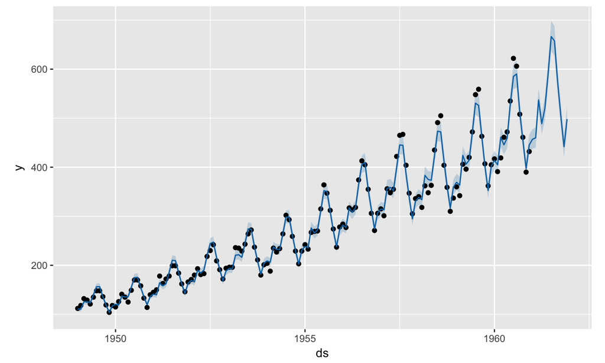

```r
plot(m, forecast)
```

## Modern Method: `prophet`

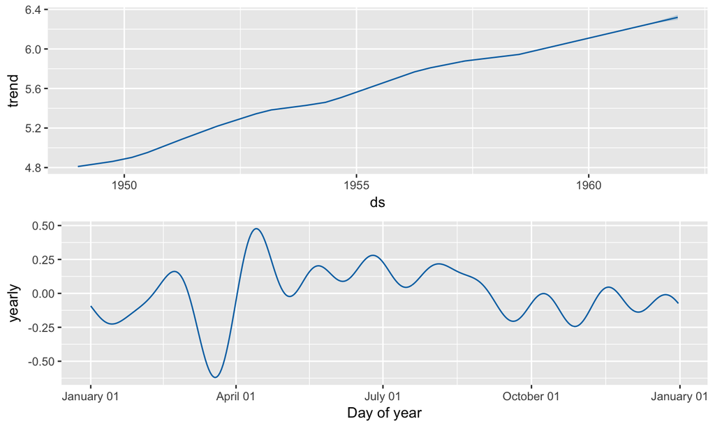

```r
prophet_plot_components(m, forecast)
```

## How Does `prophet` Work?

- **NOT** AutoRegressive (rather, finds a *curve*)
- Robust against
  - missing data
  - outliers
  - significant trend changes
- Fully automatic
- Fast at internet-scale data

\[Y = level + trend + seasonality + holidays + noise\]

## Practical Challenge

## Practical Challenge

- Open `day1/data/prophet-AirPassengers-long.R`
- Run the file
  - it will predict 10 years using
    - `prophet` and
    - `auto.arima`
- You will receive two plots (use the arrows to navigate between them)
- Which forecast is more sensible?

## Recap

## Recap

- Old methods rule the game
- …but modern methods make way for easier forecasting - they *democratise* forecasting
- For example, `prophet` offers a low-cost, high-scale platform
- A cost-effcient way to experiment (and to forecast, too)
- you can do **low-cost** experiments with **automated** methods, use e.g.
  - `prophet`
  - `auto.arima()` from the `forecast` package
- Try both!